# Traffic_Sign_Classifier_WIP_Dropout

## Project 3: Build a Traffic Sign Recognition Classifier

### Importing necessary libraries

```python
import pickle
import numpy as np
import random
import numpy as np
import matplotlib.pyplot as plt
import tensorflow as tf
import cv2
import matplotlib.pyplot as plt
import glob
import csv
import re
from tensorflow.contrib.layers import flatten
from sklearn.utils import shuffle
%matplotlib inline
```

### Function Definitions

```python
def normalize(image_data):

    return (image_data-128.)/128.


def Network(x,keep_prob):
    # Arguments used for tf.truncated_normal, randomly defines variables for the weights and biases for each layer
    mu = 0
    sigma = 0.1

    # Layer 1: Convolutional. Input = 32x32x3. Output = 28x28x6.
    conv1_W = tf.Variable(tf.truncated_normal(shape=(5, 5, 3, 6), mean = mu, stddev = sigma))
    conv1_b = tf.Variable(tf.zeros(6))
    conv1   = tf.nn.conv2d(x, conv1_W, strides=[1, 1, 1, 1], padding='VALID') + conv1_b

    # Activation.
    conv1 = tf.nn.relu(conv1)
    conv1 = tf.nn.dropout(conv1, keep_prob)

    # Pooling. Input = 28x28x6. Output = 14x14x6.
    conv1 = tf.nn.max_pool(conv1, ksize=[1, 2, 2, 1], strides=[1, 2, 2, 1], padding='VALID')
    conv1 = tf.nn.dropout(conv1, keep_prob)

    # Layer 2: Convolutional. Output = 10x10x16.
    conv2_W = tf.Variable(tf.truncated_normal(shape=(5, 5, 6, 16), mean = mu, stddev = sigma))
    conv2_b = tf.Variable(tf.zeros(16))
    conv2   = tf.nn.conv2d(conv1, conv2_W, strides=[1, 1, 1, 1], padding='VALID') + conv2_b

    # Activation.
    conv2 = tf.nn.relu(conv2)
    conv2 = tf.nn.dropout(conv2, keep_prob)

    # Pooling. Input = 10x10x16. Output = 5x5x16.
    conv2 = tf.nn.max_pool(conv2, ksize=[1, 2, 2, 1], strides=[1, 2, 2, 1], padding='VALID')
    conv2 = tf.nn.dropout(conv2, keep_prob)

    #  Flatten. Input = 5x5x16. Output = 400.
    fc0   = flatten(conv2)

    # Layer 3: Fully Connected. Input = 400. Output = 120.
    fc1_W = tf.Variable(tf.truncated_normal(shape=(400, 120), mean = mu, stddev = sigma))
    fc1_b = tf.Variable(tf.zeros(120))
    fc1   = tf.add(tf.matmul(fc0, fc1_W),fc1_b)

    # Activation.
    fc1   = tf.nn.relu(fc1)
    fc1   = tf.nn.dropout(fc1, keep_prob)

    # Layer 4: Fully Connected. Input = 120. Output = 84.
    fc2_W = tf.Variable(tf.truncated_normal(shape=(120, 84), mean = mu, stddev = sigma))
    fc2_b = tf.Variable(tf.zeros(84))
    fc2   = tf.add(tf.matmul(fc1, fc2_W),fc2_b)

    # Activation.
    fc2   = tf.nn.relu(fc2)
    fc2   = tf.nn.dropout(fc2, keep_prob)

    # Layer 5: Fully Connected. Input = 84. Output = 43.
    fc3_W  = tf.Variable(tf.truncated_normal(shape=(84, 43), mean = mu, stddev = sigma))
    fc3_b  = tf.Variable(tf.zeros(43))
    logits = tf.add(tf.matmul(fc2, fc3_W),fc3_b)

    return logits

def evaluate(X_data, y_data):
    num_examples = len(X_data)
    total_accuracy = 0
    sess = tf.get_default_session()
    for offset in range(0, num_examples, BATCH_SIZE):
        batch_x, batch_y = X_data[offset:offset+BATCH_SIZE], y_data[offset:offset+BATCH_SIZE]
        accuracy = sess.run(accuracy_operation, feed_dict={x: batch_x, y: batch_y,keep_prob: 1.0})
        total_accuracy += (accuracy * len(batch_x))
    return total_accuracy / num_examples
```

### Step 0: Load The Data

```python
# Load pickled data

training_file = './data/train.p'
validation_file= './data/valid.p'
testing_file = './data/test.p'

with open(training_file, mode='rb') as f:
    train = pickle.load(f)
with open(validation_file, mode='rb') as f:
    valid = pickle.load(f)
with open(testing_file, mode='rb') as f:
    test = pickle.load(f)

X_train, y_train, sizes_train, coords_train = train['features'],train['labels'], train['sizes'], train['coords']
X_valid, y_valid, sizes_valid, coords_valid  = valid['features'],valid['labels'], valid['sizes'], valid['coords']
X_test, y_test, sizes_test, coords_test  = test['features'], test['labels'], test['sizes'], test['coords']

assert(len(X_train) == len(y_train))
assert(len(X_valid) == len(y_valid))
assert(len(X_test) == len(y_test))
```

### Step 1: Dataset Summary & Exploration

The pickled data is a dictionary with 4 key/value pairs:

- `'features'` is a 4D array containing raw pixel data of the traffic sign images, (num examples, width, height, channels).
- `'labels'` is a 1D array containing the label/class id of the traffic sign. The file `signnames.csv` contains id -> name mappings for each id.
- `'sizes'` is a list containing tuples, (width, height) representing the original width and height the image.
- `'coords'` is a list containing tuples, (x1, y1, x2, y2) representing coordinates of a bounding box around the sign in the image. **THESE COORDINATES ASSUME THE ORIGINAL IMAGE. THE PICKLED DATA CONTAINS RESIZED VERSIONS (32 by 32) OF THESE IMAGES**

### Provide a Basic Summary of the Data Set Using Python, Numpy and/or Pandas

```python
# Number of training examples
n_train = len(X_train)

# Number of validation examples
n_validation = len(X_valid)

# Number of testing examples.
n_test = len(X_test)

# What's the shape of an traffic sign image?
image_shape = X_train[0].shape

# How many unique classes/labels there are in the dataset.
n_classes = len(np.unique(y_train))

print("Number of training examples =", n_train)
print("Number of validation examples =", n_validation)
print("Number of testing examples =", n_test,'\n')

print("Image data shape =", image_shape)
print("Number of classes =", n_classes)
```

```
Number of training examples = 34799
Number of validation examples = 4410
Number of testing examples = 12630

Image data shape = (32, 32, 3)
Number of classes = 43
```

### Include an exploratory visualization of the dataset

### Plotting Traffic Sign Images

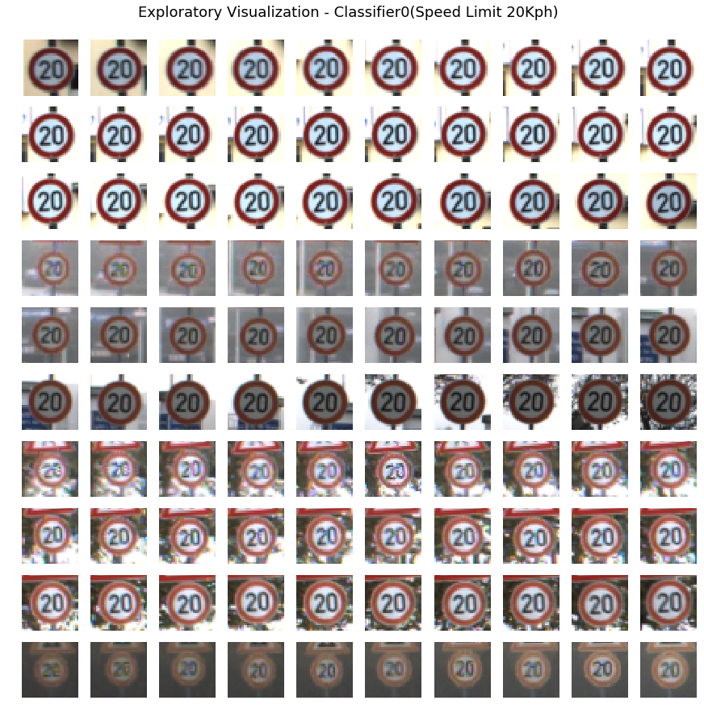

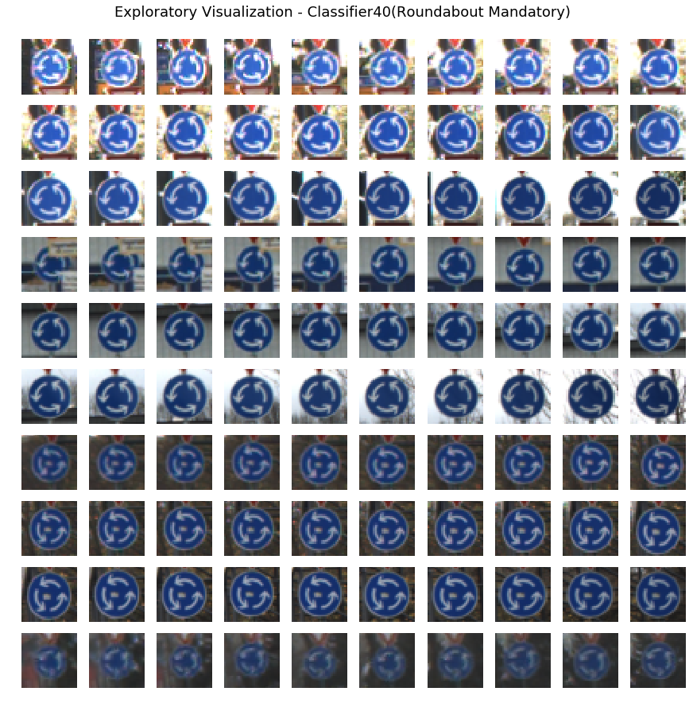

```python
i = 1
rows = 10
cols = 10

fig = plt.figure(1, figsize=(15,15))

for index in range(len(X_train)):
    if y_train[index] == 0 :
        if i <= 100:
            plt.subplot(rows, cols, i)
            plt.imshow(X_train[index])
            i=i+1
            plt.axis('off')

plt.suptitle('Exploratory Visualization - Classifier0(Speed Limit 20Kph)',fontsize=18,y =0.92)
plt.savefig('Output_Images/Comparison_Sign0.png')

fig = plt.figure(2, figsize=(15,15))

i=1
for index in range(len(X_train)):
    if y_train[index] == 40 :
        if i <= 100:
            plt.subplot(rows, cols, i)
            plt.imshow(X_train[index])
            i=i+1
            plt.axis('off')

plt.suptitle('Exploratory Visualization - Classifier40(Roundabout Mandatory)',fontsize=18,y =0.92)
plt.savefig('Output_Images/Comparison_Sign40.png')
```

### Plotting Count of Signs

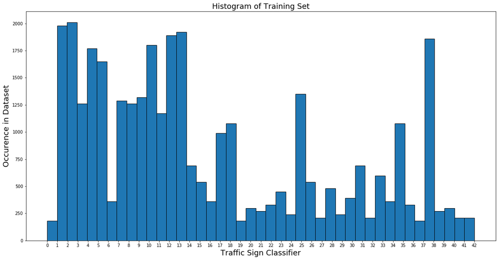

```python
# Plotting histogram of Training Set
plt.rcParams["patch.force_edgecolor"]=True
plt.figure(figsize=(20,10))
n, bins, patches = plt.hist(y_train, n_classes)
plt.xlabel('Traffic Sign Classifier',fontsize=18)
plt.xticks(range(0, n_classes, 1))
plt.ylabel('Occurence in Dataset',fontsize=18)
plt.title('Histogram of Training Set',fontsize=18)
plt.savefig('Output_Images/Training_Set.png')
```

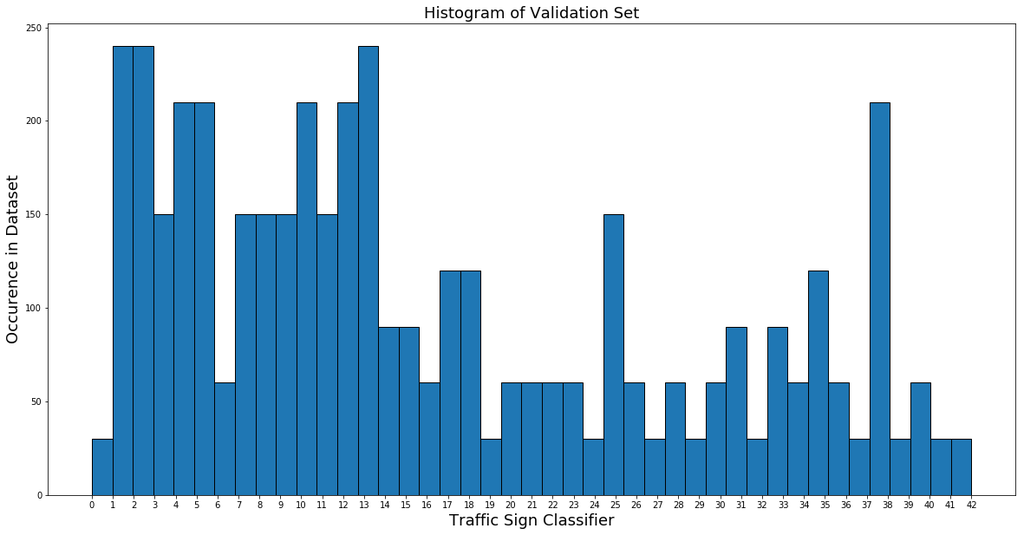

```python
# Plotting histogram of Validation Set
plt.rcParams["patch.force_edgecolor"]=True
plt.figure(figsize=(20,10))
n, bins, patches = plt.hist(y_valid, n_classes)
plt.xlabel('Traffic Sign Classifier',fontsize=18)
plt.xticks(range(0, n_classes, 1))
plt.ylabel('Occurence in Dataset',fontsize=18)
plt.title('Histogram of Validation Set',fontsize=18)
plt.savefig('Output_Images/Validation_Set.png')
```

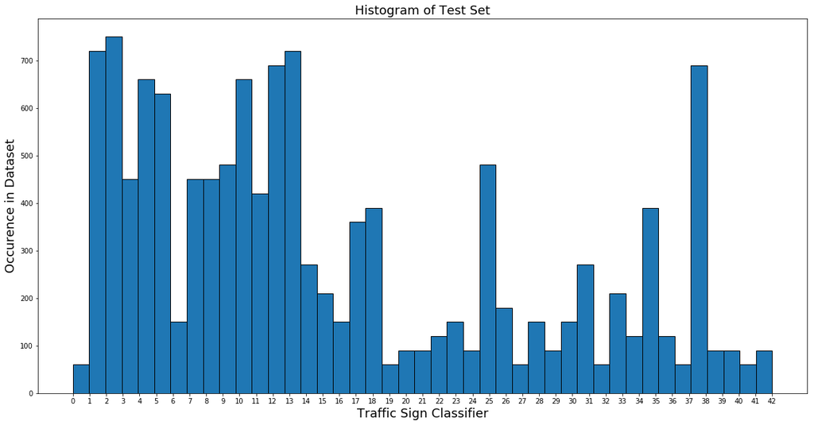

```python
# Plotting histogram of Test Set
plt.rcParams["patch.force_edgecolor"]=True
ax = plt.figure(figsize=(20,10))
n, bins, patches = plt.hist(y_test, n_classes)
plt.xlabel('Traffic Sign Classifier',fontsize=18)
plt.xticks(range(0, n_classes, 1))
plt.ylabel('Occurence in Dataset',fontsize=18)
plt.title('Histogram of Test Set',fontsize=18)
plt.savefig('Output_Images/Test_Set.png')
```

## Step 2: Design and Test a Model Architecture

### Pre-process the Data Set

```python
### Preprocess the data here.
X_train, y_train = shuffle(X_train, y_train)

X_train = normalize(X_train)
X_valid = normalize(X_valid)
X_test = normalize(X_test)
```

## Features and Labels

```python
x = tf.placeholder(tf.float32, (None, 32, 32, 3))
y = tf.placeholder(tf.int32, (None))
one_hot_y = tf.one_hot(y, 43)
```

## HyperParameters

```python
rate = 0.001
EPOCHS = 40
BATCH_SIZE = 128
```

### Training

```python
keep_prob =  tf.placeholder(tf.float32)

logits = Network(x,keep_prob)
cross_entropy = tf.nn.softmax_cross_entropy_with_logits(labels=one_hot_y, logits=logits)
loss_operation = tf.reduce_mean(cross_entropy)
optimizer = tf.train.AdamOptimizer(learning_rate = rate)
training_operation = optimizer.minimize(loss_operation)

correct_prediction = tf.equal(tf.argmax(logits, 1), tf.argmax(one_hot_y, 1))
accuracy_operation = tf.reduce_mean(tf.cast(correct_prediction, tf.float32))
saver = tf.train.Saver()
```

[output not shown]

## Train the Model

```python
with tf.Session() as sess:
    sess.run(tf.global_variables_initializer())
    num_examples = len(X_train)

    print("Training...")
    print()
    for i in range(EPOCHS):
        X_train, y_train = shuffle(X_train, y_train)
        for offset in range(0, num_examples, BATCH_SIZE):
            end = offset + BATCH_SIZE
            batch_x, batch_y = X_train[offset:end], y_train[offset:end]
            sess.run(training_operation, feed_dict={x: batch_x, y: batch_y, keep_prob: 0.9})

        training_accuracy = evaluate(X_train, y_train)
        validation_accuracy = evaluate(X_valid, y_valid)
        print("EPOCH {} ...".format(i+1))
        print("Training Accuracy = {:.3f}".format(training_accuracy))
        print("Validation Accuracy = {:.3f}".format(validation_accuracy))
        print()

    saver.save(sess, './ModelSaveFiles')
    print("Model saved")
```

[output not shown]

## Step 3: Test a Model on New Images

To give yourself more insight into how your model is working, download at least five pictures of German traffic signs from the web and use your model to predict the traffic sign type.

### Load and Output the Images

```python
images = glob.glob('web_images/*.jpg')
imageNew = np.zeros((len(images),32,32,3))
web_vals = np.zeros([len(images)],dtype=int)
fig = plt.figure(3, figsize=(15,15))
i=0

# Load web images and corresponding classifier

for fname in images:
    img = plt.imread(fname)
    web_vals[i] = re.search('/(.+?)_', fname).group(1)
    imageNew[i] = normalize(cv2.resize(img, (32, 32)))
    i+=1

pred = tf.argmax(logits,1)

# Loading classifier labels

classification = np.empty(43, dtype='object')
with open('signnames.csv') as csv_file:
    csv_reader = csv.reader(csv_file, delimiter=',')
    line_count = 0

    for row in csv_reader:
        if line_count != 0:
            #print(f'\t{row[0]} is used to classify the {row[1]}')
            classification[line_count-1] = row[1]
            line_count += 1
        else:
            line_count += 1
            pass
    print(f'Processed {line_count-1} lines.')
```

```
Processed 43 lines.
```

```python
## Test the Neural Network Model with Test images Dataset

with tf.Session() as sess:
    #sess.run(tf.global_variables_initializer())
    saver.restore(sess,'./ModelSaveFiles')
    training_accuracy = evaluate(X_train, y_train)
    validation_accuracy = evaluate(X_valid, y_valid)
    test_accuracy = evaluate(X_test, y_test)
    print("Training Accuracy = {:.5f} or {:.3%}".format(training_accuracy,training_accuracy))
    print("Validation Accuracy = {:.5f} or {:.3%}".format(validation_accuracy,validation_accuracy))
    print("Test Accuracy = {:.5f} or {:.3%}".format(test_accuracy,test_accuracy))
```

```
INFO:tensorflow:Restoring parameters from ./ModelSaveFiles
Training Accuracy = 0.99948 or 99.948%
Validation Accuracy = 0.95964 or 95.964%
Test Accuracy = 0.94521 or 94.521%
```

### Analyze Performance against Web Images

```python
with tf.Session() as sess:
    saver.restore(sess,'./ModelSaveFiles')
    prediction = sess.run(pred, feed_dict={x:imageNew, keep_prob: 1.0})
    webimage_accuracy = evaluate(imageNew, web_vals)
    print("\nWebImage Accuracy = {:.5f} or {:.3%}".format(webimage_accuracy,webimage_accuracy))
```

```
INFO:tensorflow:Restoring parameters from ./ModelSaveFiles

WebImage Accuracy = 0.90000 or 90.000%
```

### Predict the Sign Type for Each Image

```
10

Prediction |  Reality
-----------------------------
    15     |     15
    28     |     28
    17     |     17
     9     |      9
    11     |     11
    22     |     31
    18     |     18
    22     |     22
    12     |     12
    11     |     11
-----------------------------
```

[figure not shown]

```python
## Test 5 images from the web

fig = plt.figure(3, figsize=(15,15))
images = glob.glob('web_images/*.jpg')
print(len(prediction))

for index in range(len(prediction)):
    img = plt.imread(images[index])
    plt.subplot(3, 5, index+1)
    plt.imshow(img)
    title = "Prediction: " + str(prediction[index]) + " \n"  + classification[prediction[index]]
    plt.title(title,fontsize=12,y = -0.3)
    index=index+1
    plt.axis('off')
plt.tight_layout(pad=0., w_pad=0., h_pad=0.)
plt.savefig('Output_Images/web_image_comparison.png')

print('\nPrediction |  Reality')
print("-----------------------------")
for i, j in zip(prediction, web_vals):
    print('    {0:2d}     |     {1:2d} '.format(i, j))
print("-----------------------------")
```